# Statistical Principles & Experimental Design Seminar 2 on Probability

matthias.kuhn@tu-dresden.de

November 3, 2023 <sub>[4a04107]</sub>

**(solutions interspersed)**

## Darts game

When playing darts, you repeatedly throw a dart at a round board and receive a score corresponding to the number assigned to the region in which the dart gets stuck. Let’s assume that the probability of the dart hitting a particular region is *proportional to the area* of the region. The radius of the board is —say— $r$ and we have six regions which are circumscribed by six concentric circles with radii going uniformly from $\frac{r}{6}$ up to $r$.

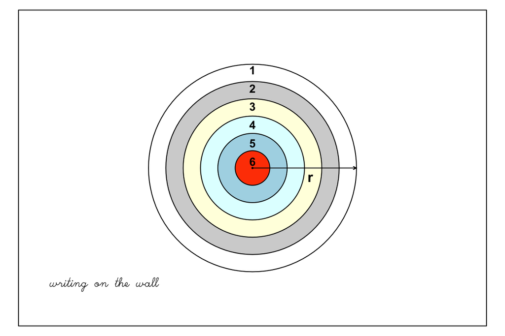

### Variant 1: Optimistic

Imagine that you *always* hit the dart board. Then there are six possible outcomes.

1. What are the physically motivated probabilities $P_1$ for the 6 regions on the board?
2. Show that Kolmogorov’s axioms are fulfilled. For axiom 3, it is enough to consider two disjoint events.

#### Solution

1. The six ring regions R<sub>1</sub>, …, R<sub>6</sub> form the atomic events of this random experiment. Hence, the sample space is Ω<sub>1</sub> = {R<sub>1</sub>, R<sub>2</sub>, R<sub>3</sub>, R<sub>4</sub>, R<sub>5</sub>, R<sub>6</sub>}. The area of the whole board is $A_B = π · r^2$. A ring R<sub>i</sub> on the board has area $A_{R_i} = π · \Big(\frac{6+1-i}{6}r\Big)^2 - π · \Big(\frac{6-i}{6}r\Big)^2 = π · r^2 \frac{13 - 2i}{36}$. Hence, we define a **generalized Laplace probability** $P_1$ on the atomic events R<sub>i</sub> as R<sub>i</sub>’s proportion of the whole board $A_B$ as
$$P_1(\{R_i\}) = \frac{π · \frac{13 - 2i}{6^2}r^2}{π r^2} = \frac{13 -
2i}{36}$$
From there, the probabilities for any subset A ⊆ Ω are defined as the sum of probabilities of all atomic events that fall into $A$.

2. Kolmogorov’s axioms are indeed fulfilled.

1. All our probabilities are proportions and hence, non-negative.
2. Here, Ω consists of all six rings and hence, $P_1(Ω) = \sum_{i=1}^6 \frac{13 - 2i}{36} = \frac{6 · 13 - 2 Σi}{36} = \frac{78 - 2 · 21}{36} = 1$.
3. We have a finite sample space Ω and it is therefore enough to consider *finite* unions of disjoint event. We examplify the 3<sup>rd</sup> axiom for a union of two disjoint events $A$ and $B$. Events $A = ⨃_{i∈I_A} R_i$ and $B = ⨃_{j ∈ I_B} R_j$ are disjoint if and only if their index sets are disjoint, $I_A ∩ I_B = ø$. Then, according to our definition, $P_1(A ⨃ B) = P_1(⨃_{k ∈ I_A ∪ I_B} R_k) = ∑_{k ∈ I_A ∪ I_B} P_1(R_k) = ∑_{i ∈ I_A} P_1(R_i) + ∑_{j ∈ I_B} P_1(R_j) = P_1(A) + P_1(B)$.

### Variant 2: Pessimistic

Imagine that the board is mounted on a wall which has a total area of $A_T > π · r^2$ and a dart always hits somewhere at the wall or the board. Missing the board is scored with 0 points. Again, the probability of hitting a region can be considered proportional to its area.

1. What is the resulting probability function $P_2$?
2. What about $P_3$, the probability function that is defined as a conditional probability of $P_2$, namely $P_3(C) := P_2( \; C \; | \text{ «board is hit»})$ for an event $C$?

#### Solution

1. The new sample space is Ω<sub>2</sub> = {R<sub>1</sub>, R<sub>2</sub>, R<sub>3</sub>, R<sub>4</sub>, R<sub>5</sub>, R<sub>6</sub>, W} where the outcome $W$ is «wall is hit». The wall that is *not* covered by the board has an area of $A_W = A_T - π · r^2$ and we assign to atomic event {W} a probability of $P_2(\{W\}) = \frac{A_W}{A} = \frac{A_T - π ·r^2}{A_T} = 1 - \frac{π · r^2}{A_T}$.
For the dart board, we have a remaining probability mass of $\frac{π · r^2}{A_T}$. For each ring $R_i$ we assign its share proportionally to its size and get:
$$P_2(R_i) = \frac{\frac{13 - 2i}{36} · π r^2}{A_T} = \frac{13 - 2i}{36} ·
\frac{π r^2}{A_T}$$
It is $P_2(R_i) < P_1(R_i)$ because the relative area of the rings becomes less as soon as we consider the wall.

2. By conditioning on event B := «board is hit» which is the complement of the atomic event $\{W\}=$ «wall is hit», we are actually back to the optimistic variant 1, with probability of zero for events that lie outside the board. We have (according to the definition of conditional probability)
$$P_3(\{R_i\}) = P_2(\{R_i\} | B) = \frac{P_2({ R_i} ∩ B)}{P_2(B)} =
\frac{P_2({R_i})}{P_2(B)}
= \frac{\frac{13 - 2i}{36} · \frac{π ·
r^2}{A_T}}{1-(1-\frac{π ·r^2}{A_T})} = \frac{13 - 2i}{36} = P_1({R_i})$$

## Independent Events

1. Let $A$ and $B$ be two events in a given probability space. If $A$ and $B$ are stochastically independent show that $A$ and $\bar B$ (i.e., the complement of $B$) are also independent.
2. What is the probability to throw at least one ⚅ in 5 rolls of a regular fair dice with six faces? Can you deduce the functional relationship that links number of rolls to the probability? Plot it. Use ggplot2’s `geom_function`.

#### Solution

1. We are given that $A$ and $B$ are independent events. This means that $P(A ∩ B) = P(A) · P(B)$ holds. We have to show that the same equation holds for $\bar B$ instead of $B$. It is:
$$\begin{align*}
P(A) &= P(A ∩ Ω) = P(A ∩ (B ∪ \bar B)) \\
&= P(A ∩ B \; \dot ∪ \; A ∩ \bar B) \\
&= P(A ∩ B) + P(A ∩ \bar B) = P(A) · P(B) + P(A ∩ \bar B)
\end{align*}$$
Rearranging terms we see: $P(A ∩ \bar B) = P(A) - P(A) · P(B) = P(A) · (1-P(B)) = P(A) · P(\bar B)$.

2. We consider the complement event «no six in five rolls» because this makes derivation easier. First, the probability to have no ⚅ in *one* toss of a dice is $\frac{5}{6}$. No ⚅ in *five* rolls has probability of $\big(\frac{5}{6}\big)^5$ because we can safely assume that each cast of the dice is independent of the others. Then,
$$P(\text{«at least one ⚅ in five rolls»}) = 1 - \big(\frac{5}{6}\big)^5 ≈
0.598$$

To show the same result *directly*, we would calculate the probability of the union of the five events «exactly one ⚅ in five rolls», «exactly two ⚅ in five rolls», …, «exactly five ⚅ in five rolls». These five individual events are mutually disjoint and are in fact *elementary events* of the *binomial distribution* with `n=5` trials and number of ⚅ (as successes) ranging from `k=1` to `k=5`. Hence, the probability of the union is just the sum of the individual probabilities.
$$P\big(\text{«exactly one ⚅ in five rolls»} ∪ \text{«exactly two ⚅ in
five rolls»} \,∪\, ... \,∪\, \text{«exactly five ⚅ in five rolls»} \big)$$
The respective probabilities of the binomial elementary events are given by the following table and these probabilities sum up to the result:

Individual probabilities according to binomial distribution

| Nbr of ⚅ | Probability |
| --- | --- |
| 1 | 0.40188 |
| 2 | 0.16075 |
| 3 | 0.03215 |
| 4 | 0.00322 |
| 5 | 0.00013 |

Finally, we can draw this probability of at least one six depending on the number of tosses:

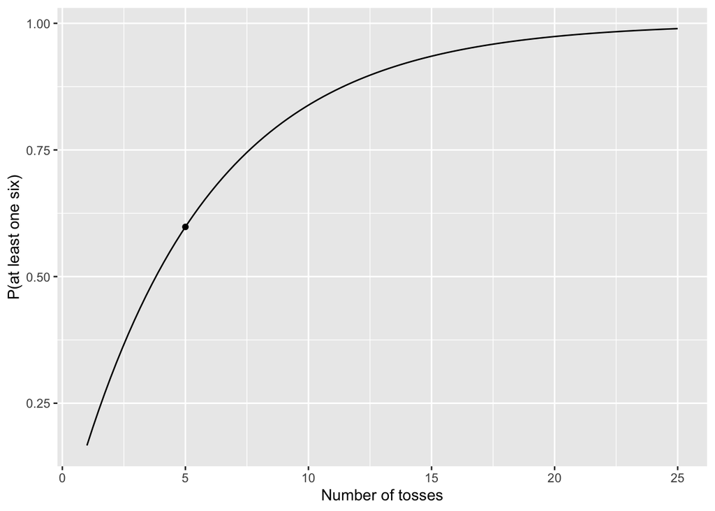

```r
library("ggplot2")
p_oneSixFun <- function(x) 1-(5/6)^x
ggplot() + xlim(1, 25) + geom_function(fun = p_oneSixFun) +
  labs(x = "Number of tosses", y = "P(at least one six)") +
  geom_point(mapping = aes(x=5, y = p_oneSixFun(5)))
```

## Reliability Theory

A statistician is asked to compare two air plane designs with respect to their safety:

1. a **three-engined design** with a main engine and two side engines. It will crash when either the main engine fails or both side engines.
2. a **four-engined design** with two side engines on the left and the right. The plane crashes if both engines of one side fail.

It can be assumed that engine failures occur independently of each other and that the failure probability (per 100,000 km) is

- for a side engine: $\;p \in (0, 1)$
- for a main engine: $\,α \cdot p \in (0, 1)$ for an $α \in (0, 1)$

Can you specify conditions under which the 4-engine design is safer than the 3-engine design? The answer ultimately depends on the values for $p$ and α.

#### Solution

We define the events C<sub>i</sub>:= «plane with *i* engines crashes». Using the **general additivity theorem** of probability and the assumed **independence** of the individual engine failure events we can calculate:
$$\begin{align*}
P(C_3) &= P( ME ∪ (SE_L ∩ SE_R)) \\
&= P( ME ) + P(SE_L ∩ SE_R) - P(ME ∩ SE_L ∩ SE_R) \\
&= α p + p^2 - αp^3 \\[1ex]
P(C_4) &= P( (SE_{L1} ∩ SE_{L2}) ∪ (SE_{R1} ∩ SE_{R2}) ) \\
&= P(SE_{L1} ∩ SE_{L2}) + P(SE_{R1} ∩ SE_{R2}) - P(SE_{L1} ∩
SE_{L2} ∩ SE_{R1} ∩ SE_{R2}) \\
&= p^2 + p^2 - p^4
\end{align*}$$

We compare the crash probabilities of the two designs and to this end we define a function $f$ with two parameters p and α as
$$\begin{align*}
f(p, α) &:= P(C_3) - P(C_4) \\
&= p · (α + p - αp^2 - p · (2-p^2)) \\
&= p · (α - p - α·p^2 + p^3)
\end{align*}$$

The four-engine design is safer than the three-engine design if and only if $f>0$ holds. For the positivity of $f$ we can ignore the factor $p$ (as $p$ is positive) and define $g(p, α) := α - p - α·p^2 + p^3$ and get
$$P(C_3) > P(C_4) ⇔ f(p, α) > 0 ⇔ g(p, α) = α - p - α·p^2 + p^3 >
0$$

Function $g$ is a polynomial of degree 3 and has at most three roots in the reals. Function $g$ is positive for $p>1$ and has a root for $p=1$ (no matter the value of α). For $p=0$, we see that $g(0, α) = α > 0$ and in between is at least one root. It is only a single root because $\lim_{p→-∞} g(p, α) = -∞$ and there must be another root for some $p<0$ (which we are not interested in). Setting $p=α$ we find this unique root for $p∈(0,1)$. In this relevant interval $(0,1)$ for $p$, **g>0 (and the 4-engine design is safer) if and only if $p<α$ holds.**

We visualize the graph of $f$ as a function of $p$ for different fixed values of parameter α:

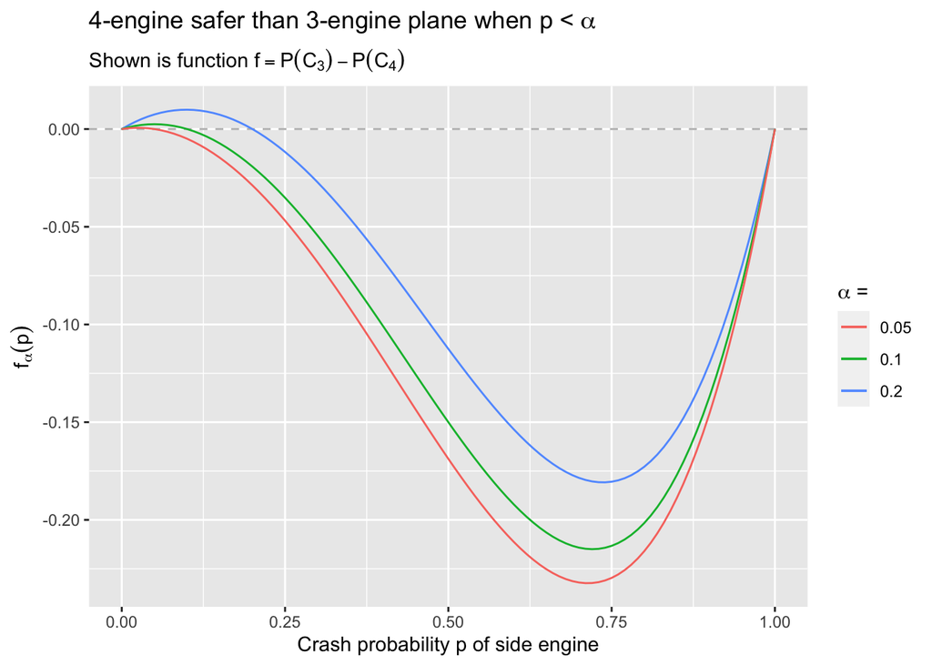

```r
ggplot() + xlim(0, 1) +
  geom_hline(yintercept = 0, linetype = 'dashed', colour = 'grey') +
  purrr::map(.x = c(0.2, .1, .05),
             .f = ~ geom_function(mapping = aes(colour = as.character(.x)),
                                  fun = saftyFun, args = list(alpha = .x))) +
  labs(x = 'Crash probability p of side engine',
       # expression() in plot labels allow for math-expressions
       # see help page for `plotmath`: ?plotmath
       y = expression(paste(f[alpha](p))),
       colour = expression(alpha * ' = '),
       title = expression('4-engine safer than 3-engine plane when p < ' * alpha),
       subtitle = expression('Shown is function ' * f == P(C[3]) - P(C[4])))
```

The 4-engine design is safer (i.e. has a lower crash probability) than the 3-engine plane when **p < α** holds.

## Probability function $P_X$ of a random variable $X$

Let the sample space Ω be the strings of length 30 that are formed by 0s and 1s. Suppose that each of the strings is equally likely, i.e., we have a Laplace probability space on Ω. We define the real-valued random variable $X$ to be *the number of 1s*.

1. How many elements are in the sample space Ω? How many elements are in the image (range) $\mathcal X$ of $X$?
2. For any $i∈\mathcal{X}$, what is $P_X(X=i)$, the probability function of $X$? Use appropriate counting rules for Laplace probabilities.
3. Looking at this probability function $P_X$, do you see a coincidence with a probability distribution from the lecture?

**Solution**

1. The sample space Ω consists of 2<sup>30</sup> strings: for each of the $k=30$ positions we draw from the $n=2$ figures 0 and 1 **with replacement** and the **order matters**. The random variable $X$ carries over the probability space from Ω to the image (range) $\mathcal{X}$ of $X$. $\mathcal{X}$ has only 31 elements, $\mathcal{X} = \{0, 1, ..., 30\}$.
2. All strings are equally likely, so we are in a Laplace probability setting and $P_X(X=i)$ is calculated as a fraction.
   - The denumerator is the number of *possible* outcomes: it is |Ω| = 2<sup>30</sup>.
   - The numerator is the number of *suitable* outcomes. We need the number of strings that contain exactly $i$ 1s. We have 30 positions and from these positions we pick $i$ positions that carry a 1 without replacement, — the order of the drawn positions does not matter. Hence, the number of different strings with $i$ 1s is $\binom{30}{i}$. So confusingly, we use the counting mode «unordered, without replacement» for the *positions of 1s* to get the number of suitable strings where its *figures 0 and 1* are ordered and with replacement.
   - Putting numerator and denumerator together, it is
     $$P_X(X=i) = \frac{\binom{30}{i}}{2^{30}}$$
3. When all strings of length 30 consisting of 0s and 1s are equally likely it means that the probabilities for the single digits 0 and 1 are both equal with $p=½$. Counting the number of 1s in these strings can then be modelled by a **binomial distribution** of size $n=30$ and $p=½$. Then, indeed, the probability mass of this binomial distribution is
   $$\begin{align*}
   P(X=i) &= \binom{30}{i} · ½^i · (1-½)^{30-i} \qquad \text{ with } n
   = 30 \text{ and } p = ½\\
   &= \binom{n}{i} · (½)^{30} \qquad \text{ as } p = 1-p = ½\\
   &= \frac{\binom{30}{i}}{2^{30}}
   \end{align*}$$

## Random Point on a Square

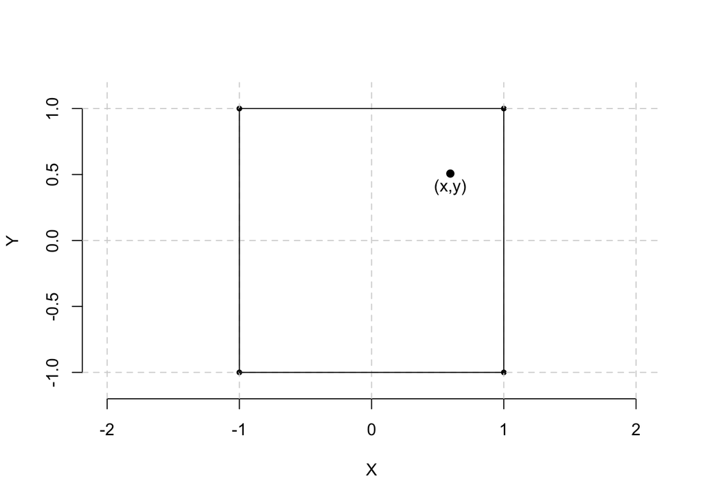

On the shown square, a random point (X,Y) is distributed **uniformly**, i.e. the joint probability density function is $f(x,y) = ¼$ on the square and $f≡0$ outside of the square.

Determine the probabilities of the following events (which are all subsets in ℝ<sup>2</sup>):

1. A = { (X,Y) ∈ ℝ<sup>2</sup> | 2X - Y > 0 }
2. B = { (X,Y) ∈ ℝ<sup>2</sup> | |X + Y| < 2 }

**Solution**

1. We consider the region A = { (x,y) ∈ ℝ<sup>2</sup> | 2x - y > 0, -1 < x < 1, -1 < y < 1 } = { (x,y) ∈ ℝ<sup>2</sup> | y/2 < x < 1, -1 < y < 1 }.
   $$\begin{align}
   P(A) = P(2X-Y > 0) &= \iint_A ¼ \, dx dy = \int_{-1}^1
   \int_{\frac{y}{2}}^1 ¼ \, dx dy \\
   &= \int_{-1}^1 ¼ x \Big|_{x=y/2}^{x=1}dy = ¼ \int_{-1}^1 1 -
   \frac{y}{2} dy \\
   &= ¼ · (y - \frac{y^2}{4})\Big|_{y=-1}^{y=1} = ¼ · [1 -
   \frac{1}{4} - (-1 - \frac{1}{4})] \\
   &= \frac{8}{16} = \frac{1}{2}
   \end{align}$$
2. We use the complement event within the square to calculate the probability of B = { (x,y) ∈ ℝ<sup>2</sup> | |x+y| < 2}.
   $$P(B) = P(|X+Y| < 2) = 1 - P(|X+Y| ≥ 2) = 1 - P({(-1,-1)}) -
   P({(+1,+1)}) = 1$$

## Gamblers versus Leibniz

Gamblers know from experience that 9 is a more likely outcome than 10 when rolling two fair six-sided dice and forming the sum.  
17<sup>th</sup> century philosopher and mathematician *Gottfried Wilhelm Leibniz* was intrigued by this fact and could not explain this. To him, both outcomes should be **equally likely** because both outcomes are formed by the same number of combinations:

- 9 is either ⚃ + ⚄ *or* ⚂ + ⚅
- 10 is either ⚄ + ⚄ *or* ⚃ + ⚅

Can you help Gottfried?

**Solution**

The flaw in Leibniz’ thinking is that he apparently uses a Laplace probability for the unordered combinations and he overlooks that not all combinations are equally likely. Hence, on the sample space of $\binom{6+2-1}{2} = 21$ unordered dice combinations the probability follows in fact a *generalized* Laplace probability.

To derive the correct probabilities it is helpful to switch to an **ordered view** because in reality everything is ordered, e.g., you can think of the two dice as being coloured red and blue. In this view, we have $6^2 = 36$ possible outcomes and each has the same probability $1/36$ (Laplace). When we define a random variable $X$ as the sum of the two dice and are interested in the probability masses of the atomic events we best count all suitable outcomes in this *ordered* view. For instance, the combination ⚃ + ⚄ has two ordered suitable outcomes, namely first ⚃, then ⚄ or reversed, ⚄ first followed by ⚃. Now, we see that rolling a double ⚄ (i.e., ⚄ + ⚄) has only a single suitable outcome. We relate these counts with the 36 possible ordered outcomes. It is important that the counting for Laplace uses the **same counting-model in numerator and denominator**.
$$\begin{align*}
P(\{X = 9\}) &= \frac{2}{36} + \frac{2}{36} = \frac{1}{9}\\
P(\{X = 10\}) &= \frac{1}{36} + \frac{2}{36} = \frac{1}{12}
\end{align*}$$

To demonstrate the distribution of $X$ we can also perform a simulation study as random experiment in R. We use `map_dbl` from the `purrr`-package to repeatedly draw two (ordered) numbers from 1 to 6 with replacement and we visualize in a bar plot how the sum is distributed. We indeed note that the atomic event {X=9} has higher probability mass than {X=10}. Our derived theoretical probabilities are indicated by red lines.

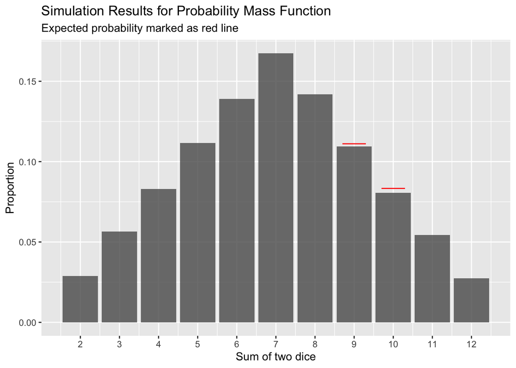

```r
library("purrr")
tibble(sum = map_dbl(seq_len(51001), \(x) sum(sample(1:6, size=2, replace=TRUE)))) |>
  # count occurrences of column "sum" and store it in column "n"
  dplyr::count(sum) |>
  dplyr::mutate(prop = n / sum(n)) |>
  ggplot(mapping = aes(x=sum, y=prop)) +
  # geom_col (and not geom_bar)
  #+because we have calculated the proportions ourselves
  geom_col(alpha = .8) +
  # highlight the theoretical probabilities
  geom_segment(data = tribble(~x, ~xend, ~y,
                              8.7,  9.3, 1/9,
                              9.7, 10.3, 1/12),
               mapping = aes(x=x, xend=xend, y = y, yend = y),
               col = "red") +
  scale_x_continuous(name = "Sum of two dice", breaks = 2:12) +
  labs(title = "Simulation Results for Probability Mass Function",
       subtitle = "Expected probability marked as red line",
       y = "Proportion")
```

## Probability Distribution of Averages <sub>*(difficult)*</sub>

In the lecture, we have seen a random experiment that naturally uses the model **unordered sampling with replacement**: Given are `n=4` integer numbers – say, the set $\{2, 4, 9, 12\}$ – from which we sample `r=4` times with replacement. We are actually not interested in the sampled numbers itself but consider instead the arithmetic mean (often simply called «average») of the sampled numbers. Of course, for the averaging, the order of the sampled numbers is irrelevant. We define the random variable $X$ as the arithmetic mean. It is a discrete random variable with only a finite number of possible realizations between 2 and 12.

What is the probability mass distribution of this random variable $X$? Write R-code that calculates the probability for each possible average value.

To simplify the task, divide it in the following sub-tasks and solve them in turn:

1. Figure out how $\binom{n+r-1}{r}$, the number of unordered samples of size $r$ from $n$ possible values with replacement, is motivated. Look up the term «stars and bars problem» in the context of combinatorics.
2. Exemplify a single draw of four numbers from the set within the notion of «stars and bars» in R:
   - First, initialize R’s pseudo-random number generator to the value 2023. Use `set.seed`.
   - Sample the *positions* of the $n-1$ «bars», separating $n$ bins, from the possible `n-1+r` positions that are taken up by $n-1$ bars and $r$ stars. The drawing of locations is actually following an «unordered, without replacement»-mode. Use R’s `sample`.
   - «Stars» have fallen where «bars» happen to be *not* in direct adjacent positions. Derive the occurrences of stars in the $n$ bins by looking for gaps between the bar positions. For instance, the sample $\{2, 4, 4, 9\}$ would correspond to the occurrences of stars $[1, 2, 1, 0]$ (*meaning:* one «2», two «4», one «9», no «12»). R’s `diff` gives you the difference of adjacent numbers in a vector. In order to use `diff` on the sampled bar positions you need to incorporate the positions of the outer bars on the very left and the very right side and to sort all bar positions.
   - Report the drawn numbers as a vector. Actually, the order of the drawn numbers does not matter to us but because in R vectors *are* ordered show the numbers in ascending order by convention. Use R’s `rep` with its parameter `times=`.
3. Construct matrices with four rows that indicate in each column a possible way how the four numbers could be sampled. Construct once the matrix of all possible occurrences and once the matrix of all possible actual samples in ascending order.
   - `combn` is a built-in R-function that generates all combinations of $n$ elements, taken $r$ at a time.
   - `rbind` allows to add a row to an existing matrix.
   - The R-function `apply` can be used to apply a function on each column of a matrix, see its help page `?apply`
4. Calculate the mean of each possible sample. `apply` again or the specialized function `colMeans`
5. Not all samples are equally likely to occur! Calculate the probability of each possible sample. Resort to the ordered perspective and use multinomial coefficients.
6. Aggregate the data per possible average value.
7. Plot the probability mass function. Use a barplot with `geom_col` or a dotplot with `geom_segment` & `geom_point`
8. Package all these steps in an own R-function that takes a vector of numbers to sample from as input and returns the data and optionally creates a plot.
9. Verify the correctness of your function by simulation: draw `r=4` numbers from {2, 4, 9, 12} with replacement, calculate the mean and repeat this `B=5000` times. Plot the observed relative frequencies in your repeated drawing together with the calculated probability masses for each average value. Do they fit? Use `replicate` or `purrr::map_dbl` to do something repeatedly. Use `dplyr`’s `left_join` to merge theoretical probability masses and observed proportions into one dataframe.

**Solution**

We build up the solution following the outline of sub-tasks given in the question.

#### Step 1

In the notion of «stars and bars», we have `n` adjacent bins (which are separated from each other by `n-1` bars) and we place `r` stars in between these bars. So, in total, we get `n-1+r` objects and each object has a unique position (ranging from 1 to `n-1+r`). The stars are indistinguishable (that’s the «unordered» aspect) and multiple stars can fall in the same bin (that’s the «with replacement» aspect). Stars in the same bin translate into star locations that are directly adjacent (i.e., no bar is in between them). So, the *locations* of the stars and bars uniquely encode the unordered draw of numbers with replacement in a one-to-one manner.

#### Step 2

We leverage the notion of «stars and bars» to draw an unordered sample of size `r` from `n` numbers with replacement. «Unordered» means that the ordering does not matter. In R, data in a vector always has an ordering. By convention, we will always use *ascending ordering* (i.e. from small to large) to present data. This way, we have a single well-defined way to present unordered data.

The preparatory R-code is:

```r
x <- c(2, 4, 9, 12) # vector to draw from
n <- length(x)
r <- length(x)

set.seed(2023) # fix state of R's pseudo-random generator
```

We use the R-function `sample` to draw the **positions of the `n-1` «bars»** that separate the `n` bins from in total `n+r-1` objects (bars & stars). The positions are drawn *without* replacement. The positions of the `n-1` bars already fix the positions of the indistinguishable stars as well. By default, `sample` (pseudo-)randomly draws from a specified vector of objects (parameter `x=`) a subset of a specified size (parameter `size=`) without replacement. From here, we use `diff` to calculate the number of «stars» that fall between two adjacent «bars». For this to work we have to add the positions `0` and `n+r` of the fixed **outer bars** on the very left and the very right side and we have to **sort** the bar locations in ascending order. The result of `diff` are the occurrences of the `n` available numbers in our draw.

```r
posBar <- c(0, sort(sample(x = 1:(n + r -1), size = n-1)) , n+r)

(occ <- diff(posBar) - 1) # occurrences of stars between the bars
```

```
## [1] 0 1 1 2
```

Finally, using `rep` we go from the occurrences to the drawn numbers itself, in ascending order.

```r
rep(x, times = occ) # drawn unordered sample in ascending order
```

```
## [1]  4  9 12 12
```

#### Step 3

We build on the previous R-code and apply it to *all possible samples* and not just a single (pseudo-)random sample. The function `combn` enumerates all possibilities to select from a given number of objects (parameter `x=`) a subset of a specified size (parameter `m=`) at a time (unordered) and without replacement as columns in a matrix. The resulting matrix has hence $\binom{x}{m}$ columns and by convention, `combn` orders the drawn elements in ascending order. `rbind` adds rows to an existing matrix. Here, we use `rbind` to add the positions of the first and the last «outer bar» to each possibility. Like in the example above, we apply the `diff`-function and subtract 1, but this time on each column of the matrix (using `apply`). We show the occurrences and actual drawn numbers of the first 9 samples.

```r
# show first nine of all possible bar locations in ascending order
combn(n + r - 1, n-1)[, 1:9]
```

```
##      [,1] [,2] [,3] [,4] [,5] [,6] [,7] [,8] [,9]
## [1,]    1    1    1    1    1    1    1    1    1
## [2,]    2    2    2    2    2    3    3    3    3
## [3,]    3    4    5    6    7    4    5    6    7
```

```r
# matrix of occurrences of the numbers
occMat <- apply(rbind(0, combn(n + r - 1, n-1), n+r),
                    MARGIN = 2, # MARGIN = 2: apply function per column
                    FUN = diff)-1
occMat[ , 1:9]
```

```
##      [,1] [,2] [,3] [,4] [,5] [,6] [,7] [,8] [,9]
## [1,]    0    0    0    0    0    0    0    0    0
## [2,]    0    0    0    0    0    1    1    1    1
## [3,]    0    1    2    3    4    0    1    2    3
## [4,]    4    3    2    1    0    3    2    1    0
```

```r
# matrix of actual drawn samples in ascending order
sampMat <- apply(occMat, 2, function(col) rep(x, times = col))
sampMat[, 1:9]
```

```
##      [,1] [,2] [,3] [,4] [,5] [,6] [,7] [,8] [,9]
## [1,]   12    9    9    9    9    4    4    4    4
## [2,]   12   12    9    9    9   12    9    9    9
## [3,]   12   12   12    9    9   12   12    9    9
## [4,]   12   12   12   12    9   12   12   12    9
```

#### Step 4

We calculate the mean of each possible sample and store it as a vector with name `avg`.

```r
(avg <- colMeans(sampMat)) # or use apply() (with FUN = mean)
```

```
##  [1] 12.00 11.25 10.50  9.75  9.00 10.00  9.25  8.50  7.75  8.00  7.25  6.50  6.00  5.25
## [15]  4.00  9.50  8.75  8.00  7.25  7.50  6.75  6.00  5.50  4.75  3.50  7.00  6.25  5.50
## [29]  5.00  4.25  3.00  4.50  3.75  2.50  2.00
```

#### Step 5

Not all samples are equally likely to occur: a sample with repeated entries has less possibilities to occur. For instance, the average of 12 only occurs when each number in the drawn sample is 12. On the other hand, we have plenty of combinations to draw a sample with all four numbers mutually different. To accommodate to this fact we treat the samples as if they were *ordered*. We count the number of possibilities that an ordered sample with replacement can occur and we will later relate this number to the total number n<sup>k</sup> of *ordered* samples with replacement to calculate the generalized Laplace probabilities for the average values in this ordered setting. It is important that the counting for Laplace uses the same counting-model in numerator and denominator.

The «multinomial coefficients» for the occurrences of the numbers give precisely the number of ordered samples. In the following code, we use R’s shorthand notation `\()` to define a function.

```r
(nbrOrderedSamples <- factorial(r) / apply(occMat, 2, \(occ) prod(factorial(occ))))
```

```
##  [1]  1  4  6  4  1  4 12 12  4  6 12  6  4  4  1  4 12 12  4 12 24 12 12 12  4  6 12  6 12
## [30] 12  6  4  4  4  1
```

#### Step 6

We aggregate our results: different unordered samples may share the same mean value. There are 35 different samples but we have only 31 possible average values. For each average value we assign the total number of possibilities that an ordered sample leads to such an average. By relating this number to the total number n<sup>r</sup> = 256 of *ordered* samples with replacement we get the **weighting** right and get the probability of this average value. Therefore, we have established the complete probability mass function: we have a finite sample space consisting of possible average values and can read out its probability. As a test the sum of all probability masses must be 1.

```r
# we use dplyr to group samples that lead to same average
# tibble() generates a dataframe with the given columns
probMassDist <- tibble(avg, nbrOrderedSamples) |>
  summarize(weight = sum(nbrOrderedSamples), .by = avg) |>
  mutate(prob = weight / n^r)

stopifnot(identical(sum(probMassDist$prob), 1)) ## check
```

*Nota bene*, the `summarize` step, which sums `nbrOrderedSamples` per value of `avg`, could be done instead via `count(avg, wt = nbrOrderedSamples)`. The advantage of `dplyr`’s `count` is that its name already makes clear that it is about summing up certain values. We will use `count` in Step 8 where we wrap up everything in a custom function.

#### Step 7

We plot the probability mass function:

- as a **barplot**:

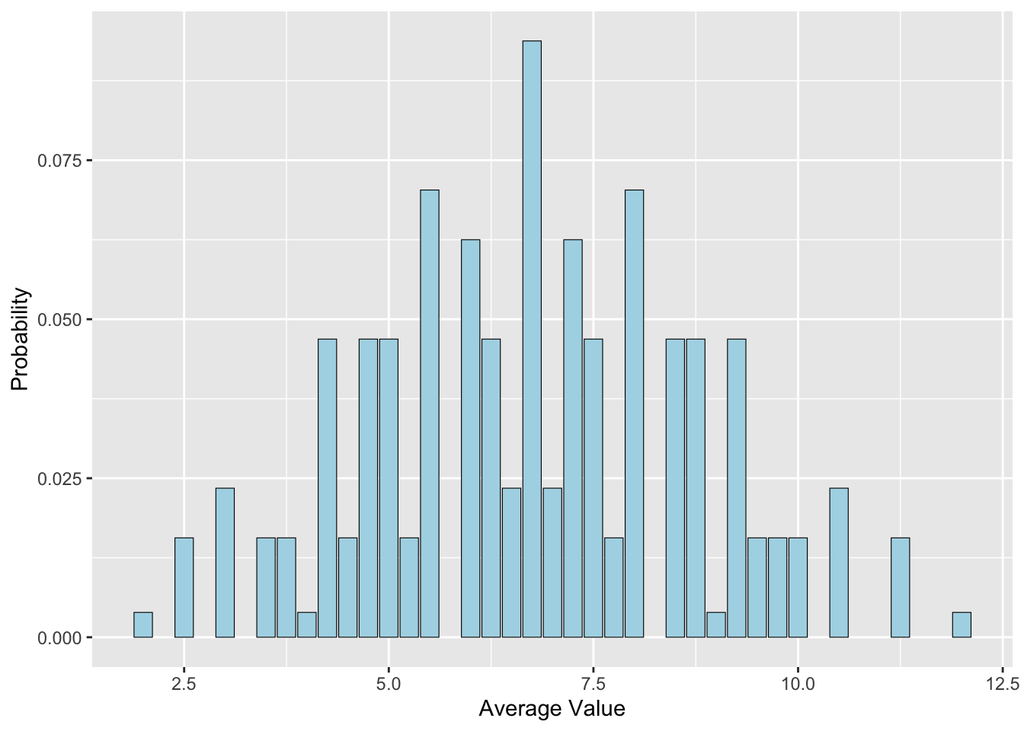

```r
#barplot(prob ~ avg_value, data = probMassDist)  ## formula interface
ggplot(data = probMassDist, mapping = aes(x = avg, y = prob)) +
  # geom_col because we have already calculated the height of the bars
  geom_col(colour = 'black', fill = 'lightblue', size=.2) +
  labs(x='Average Value', y = 'Probability')
```

- as a **dotplot** which saves some inkt:

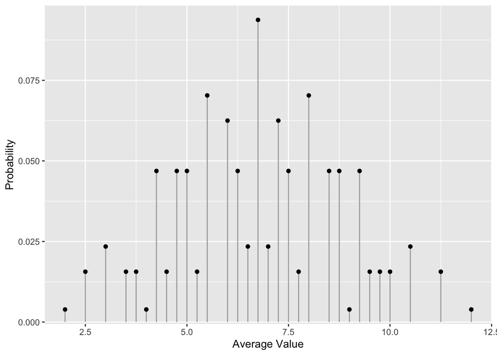

```r
ggplot(data = probMassDist, mapping = aes(x = avg, y = prob, xend = avg)) +
  geom_segment(yend = 0, col = 'darkgrey') + geom_point() +
  labs(x='Average Value', y = 'Probability')
```

Note, that the distribution of probability mass is not exactly symmetric. Still, it resembles the shape of a normal density.

#### Step 8

Now, it’s not so hard to package everything into a function called `probMass_avg`. We allow as parameters

- the available numbers to sample from (parameter `x=`),
- how many numbers to sample (parameter `r`=`)
- if we want to see the probability mass plot (parameter `plot=` as boolean flag)

```r
probMass_avg <- function(x = c(2, 4, 9, 12), r = 4, plot=TRUE){
    n <- length(x)
    occMat <- apply(rbind(0, combn(n + r - 1, n-1), n+r),
                    MARGIN = 2, # MARGIN=2: apply function per column
                    diff)-1L
    avg <- apply(occMat, 2, function(col) mean(rep(x, times = col)) )
    nbrOrderedSamples <- factorial(r) / apply(occMat, 2, \(occ) prod(factorial(occ)))

    probMassDist <- tibble(avg = avg, nbrOrderedSamples) |>
      count(avg, wt = nbrOrderedSamples, name = "weight") |>
      mutate(prob = weight / n^r)

    if (isTRUE(plot)) {
      # to display a ggplot-object from within function
      # explicitly call print on it
      print(ggplot(data = probMassDist, mapping = aes(x = avg, xend = avg, y = prob)) +
              geom_segment(yend = 0, col = 'darkgrey') + geom_point() +
              labs(x='Average Value', y = 'Probability') )

    }

    probMassDist
}
```

With our function in place, we can easily play around and vary some of the parameters:

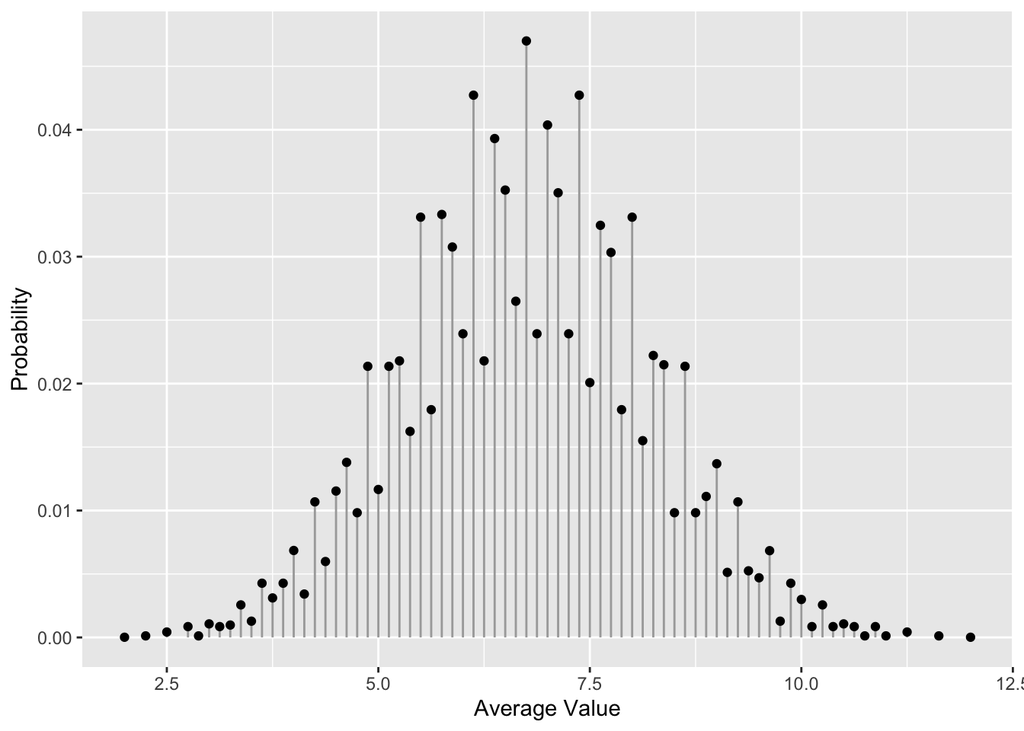

```r
probMass_avg(x = c(2, 4, 9, 12), r = 8)
```

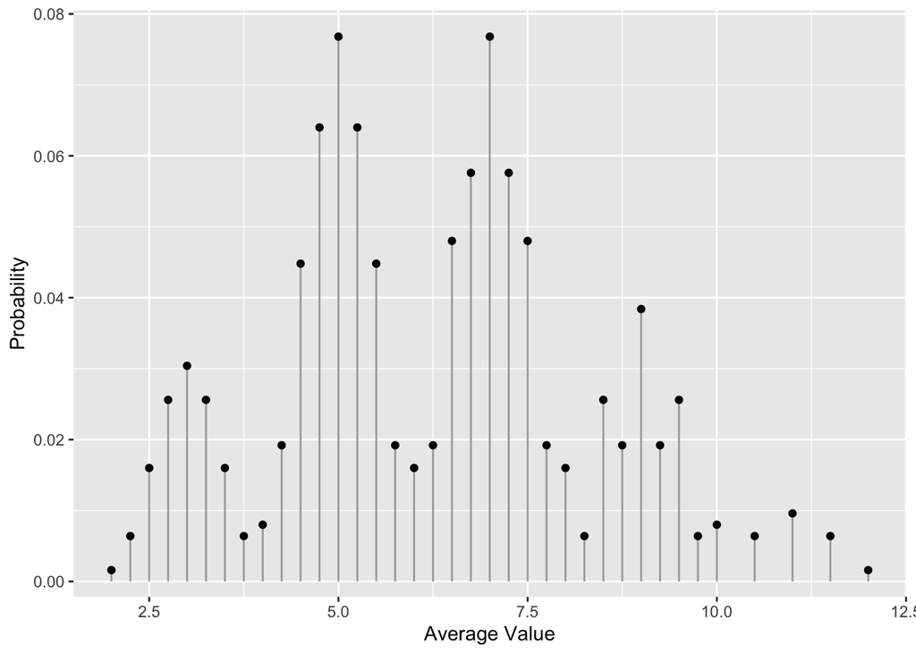

```r
probMass_avg(x = c(2, 3, 4, 10, 12), r = 4)
```

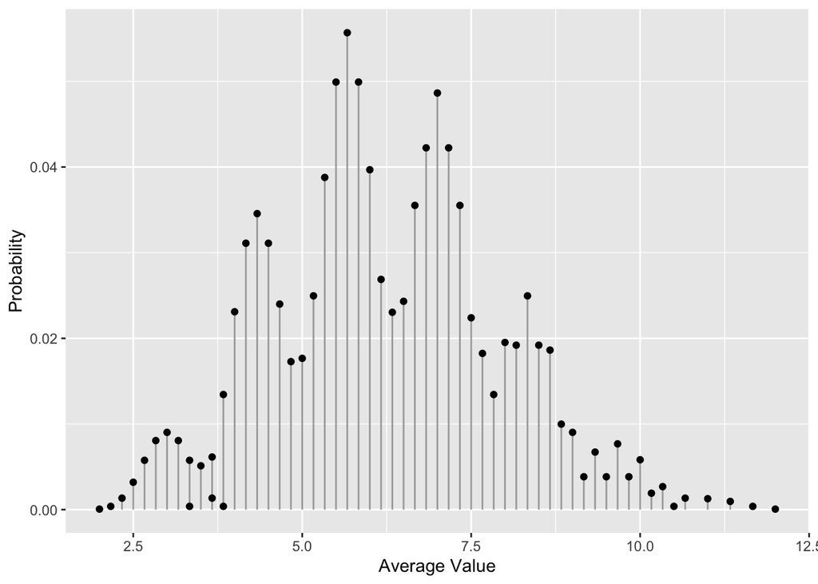

```r
probMass_avg(x = c(2, 3, 4, 10, 12), r = 6)
```

An upward outlier in the vector of numbers is visible in the probability mass plot: when we draw `r=6` times we see `r+1=7` peaks that correspond to the number of times this outlying number is sampled, form 0 times up to `r` times:

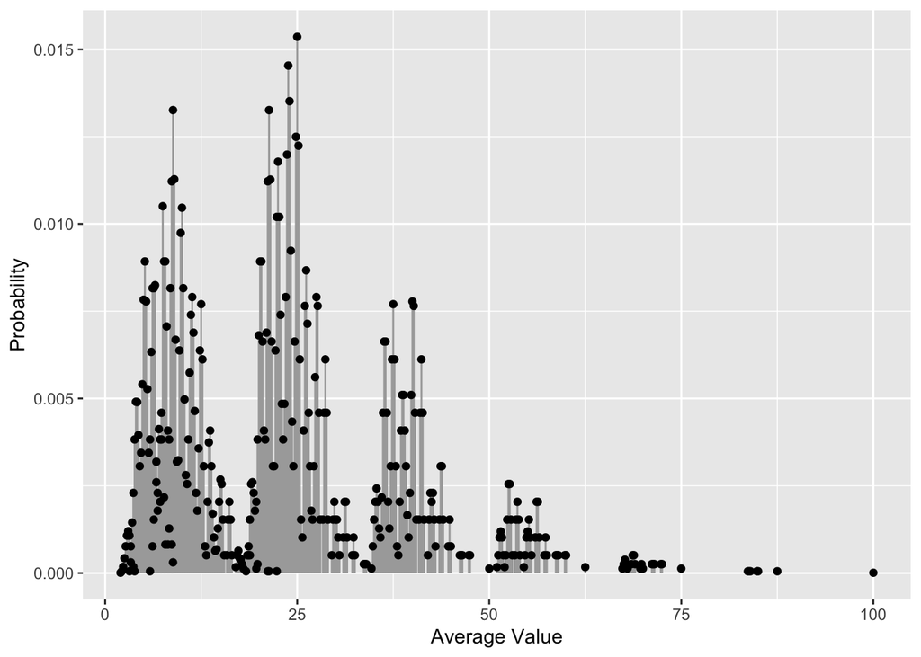

```r
probMass_avg(x = c(2, 3, 4, 9, 10, 25, 100), r = 6)
```

#### Step 9

We draw 5000 times with replacement from {2, 4, 9, 12} and calculate the means. The observed counts of means and their relative frequencies are stored in a dataframe `propObsDF`. Finally, we merge our observed proportions with the theoretical probability masses (from a call to `probMass_avg`) and plot both.

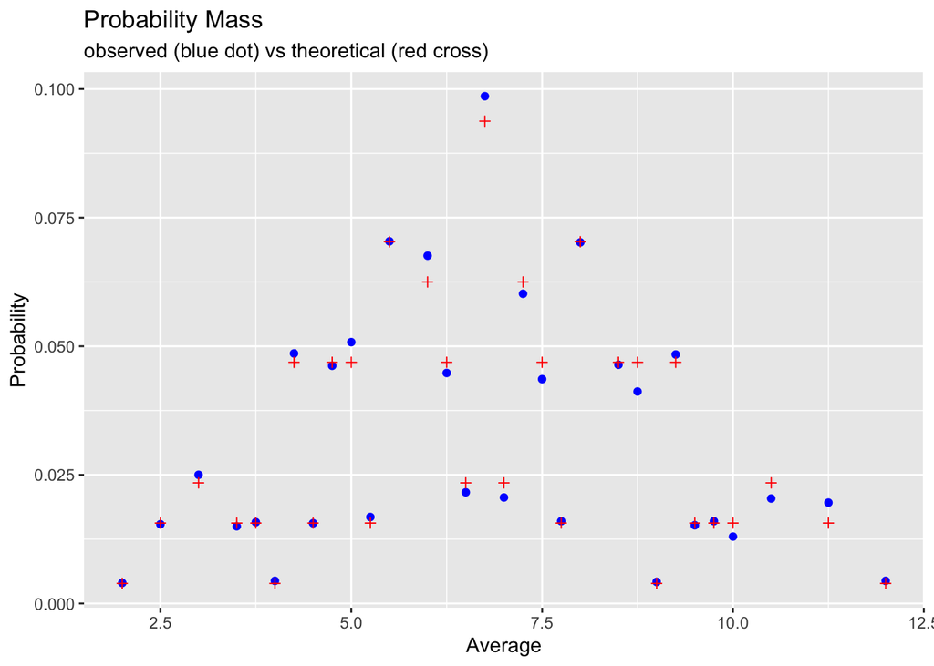

```r
library("purrr") # for functional programming (part of the tidyverse)
# map-functions allow to run a function repeatedly
sampled_avg <- map_dbl(seq_len(5000),
                       \(idx) mean(sample(c(2, 4, 9, 12), size = 4, replace = TRUE)))
# an alternative from base-R is function replicate:
#replicate(n=5000, mean(sample(c(2, 4, 9, 12), size = 4, replace = TRUE)))

# sampled average frequencies in a dataframe
propObsDF <- tibble(avg=sampled_avg) |>
  count(avg, name = "obs_n") |>
  mutate(obs_prop = obs_n / sum(obs_n))

# theoretical values
probMass_avg(x = c(2, 4, 9, 12), r = 4, plot = FALSE) |>
  # joined together with observed data
  dplyr::left_join(y = propObsDF, by = join_by(avg)) |>
  # pushed as data into ggplot for dot-plot
  ggplot(mapping = aes(x = avg, y = obs_prop)) +
  geom_point(col = "blue") +
  # add theoretical prob masses
  geom_point(mapping = aes(y = prob), col = "red", shape = 3) +
  labs(title = "Probability Mass",
       subtitle = "observed (blue dot) vs theoretical (red cross)",
       x = "Average", y = "Probability")
```

The observed relative frequencies closely follow the theoretical probability masses that we have calculated. Increasing the number of sampled averages will generally increase this agreement.